# NBA Score Prediction via Linear Model

Yo

October 17, 2018

## Scraping game scores.

Scraping all the scores up until the end of January of 2018. No comments, simply dig into this code upon your desire. We’ve covered very similar examples with college football data.

```r
library(rvest)  # Should be installed along with 'xml2'
months <- c("october","november","december","january")
all_games <- NULL

for (month_name in months){
  url_link <- paste('https://www.basketball-reference.com/leagues/NBA_2018_games-',
                    month_name,
                    '.html',
                    sep="")

  # Read the HTML webpage for that link into an R object
  url <- read_html(url_link)
  url

  # Find a 'table' on that HTML page
  table_one <- xml_find_all(url, "//table")
  # Obtain the actual contents of the table, wrapped into a data frame
  table_one <- html_table(table_one)
  length(table_one)

  all_games <- rbind(all_games,table_one[[1]])
}

head(all_games)
```

```
##                Date Start (ET)   Visitor/Neutral PTS          Home/Neutral
## 1 Tue, Oct 17, 2017      8:01p    Boston Celtics  99   Cleveland Cavaliers
## 2 Tue, Oct 17, 2017     10:30p   Houston Rockets 122 Golden State Warriors
## 3 Wed, Oct 18, 2017      7:30p   Milwaukee Bucks 108        Boston Celtics
## 4 Wed, Oct 18, 2017      8:30p     Atlanta Hawks 117      Dallas Mavericks
## 5 Wed, Oct 18, 2017      7:00p Charlotte Hornets  90       Detroit Pistons
## 6 Wed, Oct 18, 2017      7:00p     Brooklyn Nets 131        Indiana Pacers
##   PTS            Attend. Notes
## 1 102 Box Score   20,562  <NA>
## 2 121 Box Score   19,596  <NA>
## 3 100 Box Score   18,624  <NA>
## 4 111 Box Score   19,709  <NA>
## 5 102 Box Score   20,491  <NA>
## 6 140 Box Score   15,008  <NA>
```

```r
str(all_games)
```

```
## 'data.frame':    760 obs. of  10 variables:
##  $ Date           : chr  "Tue, Oct 17, 2017" "Tue, Oct 17, 2017" "Wed, Oct 18, 2017" "Wed, Oct 18, 2017" ...
##  $ Start (ET)     : chr  "8:01p" "10:30p" "7:30p" "8:30p" ...
##  $ Visitor/Neutral: chr  "Boston Celtics" "Houston Rockets" "Milwaukee Bucks" "Atlanta Hawks" ...
##  $ PTS            : int  99 122 108 117 90 131 91 109 124 105 ...
##  $ Home/Neutral   : chr  "Cleveland Cavaliers" "Golden State Warriors" "Boston Celtics" "Dallas Mavericks" ...
##  $ PTS            : int  102 121 100 111 102 140 103 116 76 100 ...
##  $                : chr  "Box Score" "Box Score" "Box Score" "Box Score" ...
##  $                : chr  "" "" "" "" ...
##  $ Attend.        : chr  "20,562" "19,596" "18,624" "19,709" ...
##  $ Notes          : chr  NA NA NA NA ...
```

```r
all_games <- all_games[,c(3:6)]   # Retain only needed info

# Convert scores from "chr" to "numeric"
all_games[,c(2,4)] <- apply(all_games[,c(2,4)],
                            2,
                            as.numeric)

str(all_games) # Now we're all set.
```

```
## 'data.frame':    760 obs. of  4 variables:
##  $ Visitor/Neutral: chr  "Boston Celtics" "Houston Rockets" "Milwaukee Bucks" "Atlanta Hawks" ...
##  $ PTS            : num  99 122 108 117 90 131 91 109 124 105 ...
##  $ Home/Neutral   : chr  "Cleveland Cavaliers" "Golden State Warriors" "Boston Celtics" "Dallas Mavericks" ...
##  $ PTS.1          : num  102 121 100 111 102 140 103 116 76 100 ...
```

## Scraping team performance stats.

Here we’ll repeat the code we used to scrape data for NBA team clustering (see the respective code), with only exception being - we’ll obtain data until Jan 31st (to include a full month of January), rather that Jan 18th.

```r
url_link <- 'https://www.basketball-reference.com/friv/standings.fcgi?month=1&day=31&year=2018&lg_id=NBA'

# Read the HTML webpage for that link into an R object
url <- read_html(url_link)
url
```

```
## {xml_document}
## <html data-version="klecko-" data-root="/home/bbr/www" itemscope="" itemtype="https://schema.org/WebSite" lang="en" class="no-js">
## [1] <head>\n<meta http-equiv="Content-Type" content="text/html; charset= ...
## [2] <body class="bbr">\n\n<div id="wrap">\n  <div id="header" role="bann ...
```

```r
# Define the function to extract the "commented out" tables.

find_extra_table <- function(url_link){
  # Additional tables are within the comment tags -  between "<!--"  and  "-->"
  # Which is why your xpath is missing them.

  # Find all the commented nodes.
  # xml_find_all looks in-between the <> of the object resulting from read_html().
  alt_tables <- xml_find_all(read_html(url_link),"//comment()")

  #Among commented nodes, find those containing '<table' reg. expression
  #raw_parts <- as.character(alt_tables[grep("\\</?table", as.character(alt_tables))])
  raw_parts <- as.character(alt_tables[grep("<table", as.character(alt_tables))])

  # Remove the comment begin ("<!--") and end ("-->") tags
  strip_html <- stringi::stri_replace_all_regex(raw_parts, c("<\\!--","-->"),c("",""),
                                                vectorize_all = FALSE)

  # Read all the tables that used to be commented before.
  alt_tables <- lapply(grep("<table", strip_html, value = TRUE), function(i){
    rvest::html_table(xml_find_all(read_html(i), "//table"))[[1]]
  })

  return(alt_tables)
}

###  Getting the needed tables.

all_stats <- find_extra_table(url_link)
team_stats <- all_stats[[1]]
opp_stats <- all_stats[[2]]

head(team_stats)
```

```
##   Rk                   Team  G    MP   FG  FGA   FG%  3P  3PA   3P%   2P
## 1  1  Golden State Warriors 51 12290 2215 4358 0.508 596 1519 0.392 1619
## 2  2        Houston Rockets 49 11810 1914 4159 0.460 764 2102 0.363 1150
## 3  3        Toronto Raptors 49 11810 2001 4289 0.467 544 1555 0.350 1457
## 4  4   New Orleans Pelicans 50 12175 2069 4259 0.486 536 1469 0.365 1533
## 5  5    Cleveland Cavaliers 49 11785 1941 4095 0.474 587 1606 0.366 1354
## 6  6 Minnesota Timberwolves 54 13035 2205 4630 0.476 417 1189 0.351 1788
##    2PA   2P%   FT  FTA   FT% ORB  DRB  TRB  AST STL BLK TOV   PF  PTS
## 1 2839 0.570  872 1071 0.814 428 1818 2246 1555 417 402 777 1004 5898
## 2 2057 0.559  998 1267 0.788 460 1682 2142 1082 437 220 684  989 5590
## 3 2734 0.533  896 1122 0.799 488 1657 2145 1118 401 298 635 1087 5442
## 4 2790 0.549  864 1132 0.763 413 1738 2151 1322 380 261 758  980 5538
## 5 2489 0.544  920 1148 0.801 409 1634 2043 1154 351 187 687  898 5389
## 6 3441 0.520 1052 1326 0.793 575 1676 2251 1221 480 227 636  961 5879
```

```r
head(opp_stats)
```

```
##   Rk                  Team  G    MP   FG  FGA   FG%  3P  3PA   3P%   2P
## 1  1     San Antonio Spurs 53 12720 1983 4425 0.448 484 1384 0.350 1499
## 2  2        Boston Celtics 51 12290 1867 4308 0.433 449 1350 0.333 1418
## 3  3            Miami Heat 50 12050 1854 4116 0.450 457 1274 0.359 1397
## 4  4 Oklahoma City Thunder 51 12340 1900 4189 0.454 553 1555 0.356 1347
## 5  5             Utah Jazz 50 12050 1887 4079 0.463 505 1345 0.375 1382
## 6  6     Memphis Grizzlies 49 11785 1765 3912 0.451 502 1348 0.372 1263
##    2PA   2P%  FT  FTA   FT% ORB  DRB  TRB  AST STL BLK TOV   PF  PTS
## 1 3041 0.493 718  961 0.747 477 1759 2236 1107 419 186 713 1026 5168
## 2 2958 0.479 854 1123 0.760 508 1744 2252 1032 356 221 698  954 5037
## 3 2842 0.492 888 1129 0.787 432 1663 2095  993 371 234 648  954 5053
## 4 2634 0.511 849 1116 0.761 474 1619 2093 1139 399 224 780 1055 5202
## 5 2734 0.505 827 1068 0.774 446 1712 2158 1028 414 227 757  980 5106
## 6 2564 0.493 989 1278 0.774 484 1588 2072 1033 349 260 696 1025 5021
```

```r
###  Cleaning up memory.

rm(all_stats)
team_stats$Rk <- opp_stats$Rk <- NULL
team_stats <- team_stats[-nrow(team_stats),]
opp_stats <- opp_stats[-nrow(opp_stats),]

# Next, we need to obtain **per-game averages** in such categories as
# FG made, attempted (FGM/A),  3PTM/A, FTM/A,
# offensive rebounds (ORB), DRB, TRB, AST, STL, BLK, TOV, PF, PTS.

# All but the %-type of stats (FG%, 3PT% etc).
# We can obtain indices of those %-stats and other unwanted columns (team names) as follows
# (again some data wrangling/string operations):


ind.exclude <- which(grepl("%",names(team_stats)))
ind.exclude <- c(ind.exclude, which(grepl("[a-z]",names(team_stats))))
ind.exclude
```

```
## [1]  6  9 12 15  1
```

```r
### Sub the totals for averages.

team_stats[,-ind.exclude] <- apply(team_stats[,-ind.exclude],
                                   2,
                                   function(x) x/team_stats$G)

opp_stats[,-ind.exclude] <- apply(opp_stats[,-ind.exclude],
                                  2,
                                  function(x) x/opp_stats$G)


#head(team_stats)
#head(opp_stats)

### Get rid of "G" and "MP" columns.

team_stats$G <- opp_stats$G <- NULL
team_stats$MP <- opp_stats$MP <- NULL
```

We will also use the same variables we’ve hand-picked via studying correlations and multi-collinearities when performing NBA team clustering:

```r
# Var "selection": gotta get rid of correlated and collinear stuff.

needed.vars.team <- c("FGA","FG%","3PA","3P%", "ORB", "TRB", "AST", "BLK", "TOV","PF")
needed.vars.opp <- c("FGA","FG%","3PA", "3P%",  "ORB", "TRB", "AST", "TOV")

all_stats <- merge(team_stats[,c("Team",needed.vars.team)],
                   opp_stats[,c("Team",needed.vars.opp)],
                   by = "Team")
head(all_stats)
```

```
##                  Team    FGA.x FG%.x    3PA.x 3P%.x     ORB.x    TRB.x
## 1       Atlanta Hawks 85.20000 0.451 29.60000 0.369  9.740000 41.02000
## 2      Boston Celtics 84.62745 0.448 31.82353 0.368  9.117647 44.33333
## 3       Brooklyn Nets 86.50980 0.435 34.09804 0.344 10.137255 45.62745
## 4   Charlotte Hornets 86.48980 0.440 26.08163 0.353 10.448980 46.40816
## 5       Chicago Bulls 88.72000 0.440 30.82000 0.361  9.240000 44.94000
## 6 Cleveland Cavaliers 83.57143 0.474 32.77551 0.366  8.346939 41.69388
##      AST.x      BLK    TOV.x       PF    FGA.y FG%.y    3PA.y 3P%.y
## 1 23.80000 4.280000 15.14000 20.12000 85.06000 0.473 30.44000 0.376
## 2 22.03922 4.686275 13.31373 20.33333 84.47059 0.433 26.47059 0.333
## 3 22.19608 4.058824 14.80392 20.72549 89.07843 0.459 25.37255 0.359
## 4 20.51020 4.816327 12.61224 17.85714 87.00000 0.458 29.61224 0.363
## 5 23.88000 3.700000 13.32000 19.26000 87.54000 0.466 31.24000 0.367
## 6 23.55102 3.816327 14.02041 18.32653 88.30612 0.475 31.77551 0.372
##       ORB.y    TRB.y    AST.y    TOV.y
## 1 10.460000 43.52000 25.84000 15.44000
## 2  9.960784 44.15686 20.23529 13.68627
## 3  9.921569 46.00000 21.33333 12.03922
## 4  8.306122 43.57143 23.73469 13.44898
## 5  8.380000 45.80000 25.32000 12.52000
## 6 10.408163 44.04082 26.12245 13.08163
```

## Actual Modeling.

Now that we’ve got:

- the characteristics (performance stats) of each team, kept in $all\_stats$ object,
- the scores for all NBA 2017/18 season games played until January 31st, kept in $all\_games$

we need to somehow use the **characteristics** of teams $A$ & $B$ as **predictors** for the eventual **score** of a game between $A$ & $B$. We will be using the completed games to train and test our model’s performance.

### Getting data into needed format.

Unfortunately, we’re not done getting data into needed format. We have to perform extra merging to actually put it into classic $observations \ \times variables$ format. Below code achieves that, and don’t ask me how exactly it does it (the way to get there was pretty messy).

```r
colnames(all_games)
```

```
## [1] "Visitor/Neutral" "PTS"             "Home/Neutral"    "PTS.1"
```

```r
full_data <-  merge(all_games, all_stats, by.x=c("Visitor/Neutral"), by.y=c("Team"))
p <- dim(full_data)[2]-4
full_data <- merge(full_data, all_stats, by.x=c("Home/Neutral"), by.y=c("Team"))

# The resulting 'full_data' frame was pretty messy,
# hence a weird indexation in the line below.
diff_data <- full_data[,c(4,(5+p):ncol(full_data))] - full_data[,c(3,5:(5+p-1))]
dim(diff_data)
```

```
## [1] 760  19
```

```r
head(cbind(full_data[,c(1,2)],diff_data))
```

```
##    Home/Neutral      Visitor/Neutral PTS.1    FGA.x.y FG%.x.y   3PA.x.y
## 1 Atlanta Hawks       Indiana Pacers   -10 -0.7803922  -0.030  4.972549
## 2 Atlanta Hawks Los Angeles Clippers   -13  0.5800000  -0.012  0.860000
## 3 Atlanta Hawks     Dallas Mavericks     5  0.5921569   0.004 -2.223529
## 4 Atlanta Hawks      Milwaukee Bucks   -11  4.0979592  -0.030  5.048980
## 5 Atlanta Hawks        Brooklyn Nets    -5 -1.3098039   0.016 -4.498039
## 6 Atlanta Hawks       Boston Celtics    -3  0.5725490   0.003 -2.223529
##   3P%.x.y    ORB.x.y    TRB.x.y  AST.x.y      BLK.y   TOV.x.y       PF.y
## 1  -0.004  0.8184314 -0.7250980 1.250980  0.1623529 2.3949020  1.3552941
## 2   0.015 -0.3000000 -2.2200000 1.860000 -0.6000000 0.7000000 -0.6000000
## 3   0.005  2.1125490  0.4513725 1.623529  0.4956863 3.4341176  0.6298039
## 4   0.014  2.0665306  2.3261224 1.167347 -0.8628571 2.2216327 -2.0840816
## 5   0.025 -0.3972549 -4.6074510 1.603922  0.2211765 0.3360784 -0.6054902
## 6   0.001  0.6223529 -3.3133333 1.760784 -0.4062745 1.8262745 -0.2133333
##      FGA.y.y FG%.y.y    3PA.y.y 3P%.y.y    ORB.y.y    TRB.y.y  AST.y.y
## 1 -0.7831373   0.005 -0.4423529   0.026  0.2639216  0.6964706 2.683137
## 2 -1.2600000   0.018  1.2400000   0.026 -0.4200000 -1.0200000 2.140000
## 3  2.9815686   0.009  1.2635294   0.010  1.7149020 -1.9701961 3.408627
## 4  3.6314286   0.004  4.0114286   0.006  1.3171429  1.8057143 2.962449
## 5 -4.0184314   0.014  5.0674510   0.017  0.5384314 -2.4800000 4.506667
## 6  0.5894118   0.040  3.9694118   0.043  0.4992157 -0.6368627 5.604706
##     TOV.y.y
## 1 1.1458824
## 2 0.9800000
## 3 1.8713725
## 4 0.7257143
## 5 3.4007843
## 6 1.7537255
```

The $PTS.1$ value corresponds to the score differential for the **home team** in that game. E.g. $-10$ in the first row means that home team lost by $10$ points (there’s plenty of home team losing in first 6 observations, as those are Atlanta Hawks home games …).

The rest of stats are treated similarly:

- $FGA.x.y$ corresponds to differential in average FG attempts per game for the home team ($\text{FGA for home team}$ - $\text{FGA for away team}$),
- $FG\%x.y$ is the difference in FG% for the home team ($\text{FG% for home team}$ - $\text{FG% for away team}$)
- …
- $FG\%y.y$ is the difference in FG% **allowed** for the home team ($\text{FG% allowed by home team}$ - $\text{FG% allowed by away team}$)

### Finally… modeling.

Now we can use the **stat differentials** between teams $A$ and $B$ in order to predict the **score differential** of a game between $A$ and $B$! We will refer to a classical multiple linear model, which can be fit via $lm()$ function:

```r
lm.obj <- lm(PTS.1 ~ ., data=diff_data)
summary(lm.obj)
```

```
##
## Call:
## lm(formula = PTS.1 ~ ., data = diff_data)
##
## Residuals:
##     Min      1Q  Median      3Q     Max
## -41.856  -8.226   0.068   7.102  45.143
##
## Coefficients:
##               Estimate Std. Error t value Pr(>|t|)
## (Intercept)   2.218346   0.449093   4.940 9.68e-07 ***
## FGA.x.y      -0.594365   0.521317  -1.140  0.25460
## `FG%.x.y`   137.826982  93.754191   1.470  0.14196
## `3PA.x.y`     0.447941   0.107793   4.156 3.62e-05 ***
## `3P%.x.y`    40.961709  45.670003   0.897  0.37006
## ORB.x.y       0.523571   1.926016   0.272  0.78582
## TRB.x.y       1.204221   1.526560   0.789  0.43045
## AST.x.y       0.053249   0.373958   0.142  0.88681
## BLK.y        -0.105402   1.030737  -0.102  0.91858
## TOV.x.y      -2.170401   0.724280  -2.997  0.00282 **
## PF.y          0.004401   0.382130   0.012  0.99081
## FGA.y.y       0.157878   0.877812   0.180  0.85732
## `FG%.y.y`   -69.544401 132.477771  -0.525  0.59977
## `3PA.y.y`    -0.213858   0.324921  -0.658  0.51062
## `3P%.y.y`    33.908258  66.691359   0.508  0.61130
## ORB.y.y       0.531372   1.789262   0.297  0.76657
## TRB.y.y      -0.333119   0.839227  -0.397  0.69153
## AST.y.y      -0.310486   0.557235  -0.557  0.57757
## TOV.y.y       1.542224   0.678140   2.274  0.02324 *
## ---
## Signif. codes:  0 '***' 0.001 '**' 0.01 '*' 0.05 '.' 0.1 ' ' 1
##
## Residual standard error: 12.36 on 741 degrees of freedom
## Multiple R-squared:  0.1667, Adjusted R-squared:  0.1464
## F-statistic: 8.234 on 18 and 741 DF,  p-value: < 2.2e-16
```

Let’s break down the significant variables:

- 3PT attempt differential ($3PA.x.y$) appears important, with a positive influence on a score differential (teams taking more threes per game than their opponents have a higher chance to win), which is… curious
- Positive differential in turnovers **committed** ($TOV.x.y$) has a significant **negative** impact on the score differential (teams committing more turnovers per game than their opponent have a lower chance to win), which is pretty clear.
- Positive differential in turnovers **forced** ($TOV.y.y$) has a significant **positive** impact on the score differential (teams forcing more turnovers per game than their opponent have a higher chance to win), which is also clear.
- How about the **intercept** term? This is a pretty rare occasion where it actually means something really important - **advantage of a home team**. It is equal to an average across all games by which the home team outscores the visitor. Here it is significantly higher than $0$ and shows an advantage of 2.2 points per home team on average. intercept term is here described **what’s the average score differential for a home team**. So it says that, on average, home teams beat opponents by 2.2 points.

Now, all these interpretations are great, but one has to be worried about an overflow of seemingly unimportant predictors in the model (ones with high $p$-values). There a couple of ways we can go about getting rid of irrelevant variables.

### Variance Inflation Factor.

Issue of **multi-collinearity** arises when certain predictors can be represented as linear combinations of other predictors, which leads to instability of parameter estimation in linear models. Multicollinearity reduces a model’s legitimacy and predictive power.

Sometimes multi-collinearity among predictors is pretty obvious, such as $FGA = 3PA + 2PA$, but we did take care of those by hand in the earlier stages.

But at times the multi-collinearity is sneakier and isn’t easy to spot by hand. This is where **Variance Inflation Factor (VIF)** comes in handy. **Variance inflation factors** of a **predictor** allows a quick measure of how much this predictor is **increasing (inflating)** the **standard errors** (hence, **variance**) of regression **estimates** in our linear model.

VIF of each predictor can be calculated via $vif()$ function of $car$ library.

```r
library(car)
vif(lm.obj)
```

```
##   FGA.x.y `FG%.x.y` `3PA.x.y` `3P%.x.y`   ORB.x.y   TRB.x.y   AST.x.y
##  9.268148 22.645327  2.001622  4.029451 47.052555 98.565065  5.872309
##     BLK.y   TOV.x.y      PF.y   FGA.y.y `FG%.y.y` `3PA.y.y` `3P%.y.y`
##  7.343272  6.983332  3.614322 61.528035 25.761260  4.459482  7.661466
##   ORB.y.y   TRB.y.y   AST.y.y   TOV.y.y
## 21.743406 17.436275  9.059465  3.391909
```

“Good” The values of **VIF between $1$ and $10$** are considered **good**, meaning that this predictor is not subject to multi-collinearity.

But once you get **VIF > $10$**, those variables are suspect and probably need to be removed. Here we see TRB.x.y (difference in total rebounds by the team) yielding a 98.56 VIF => let’s get rid of it.

```r
vif(lm(PTS.1 ~ .-TRB.x.y, data=diff_data))
```

```
##   FGA.x.y `FG%.x.y` `3PA.x.y` `3P%.x.y`   ORB.x.y   AST.x.y     BLK.y
##  9.127315 22.213948  1.897296  3.990388 17.010910  5.786667  7.264003
##   TOV.x.y      PF.y   FGA.y.y `FG%.y.y` `3PA.y.y` `3P%.y.y`   ORB.y.y
##  6.977551  3.421531 15.726058 10.394771  4.429147  7.344776  7.184701
##   TRB.y.y   AST.y.y   TOV.y.y
## 17.435996  8.550535  3.317310
```

One sees how most VIFs got automatically reduced once this suspect variable got eliminated, pointing to the fact that it probably had heavy collinearities with multiple predictors. Now let’s keep eliminating the predictors producing largest VIF values that end up above $10$.

```r
vif(lm(PTS.1 ~ .-TRB.x.y-`FG%.x.y`, data=diff_data))
```

```
##   FGA.x.y `3PA.x.y` `3P%.x.y`   ORB.x.y   AST.x.y     BLK.y   TOV.x.y
##  8.870620  1.798522  3.864001 10.508663  4.640486  6.303410  6.485687
##      PF.y   FGA.y.y `FG%.y.y` `3PA.y.y` `3P%.y.y`   ORB.y.y   TRB.y.y
##  3.393614 13.456341  7.974576  3.752932  6.369615  4.537797  6.098125
##   AST.y.y   TOV.y.y
##  8.158416  3.183027
```

```r
vif(lm(PTS.1 ~ .-TRB.x.y-`FG%.x.y`-FGA.y.y, data=diff_data))
```

```
##   FGA.x.y `3PA.x.y` `3P%.x.y`   ORB.x.y   AST.x.y     BLK.y   TOV.x.y
##  5.186825  1.695133  3.193751  8.457921  4.617536  5.517759  3.941313
##      PF.y `FG%.y.y` `3PA.y.y` `3P%.y.y`   ORB.y.y   TRB.y.y   AST.y.y
##  2.433109  7.457471  3.726873  5.130399  3.721780  6.032796  7.540935
##   TOV.y.y
##  1.763101
```

Now that all the remaining predictors end up in the healthy VIF range, we re-fit our linear model for that reduced set of predictors.

```r
lm.obj <- lm(PTS.1 ~ .-TRB.x.y-`FG%.x.y`-FGA.y.y, data=diff_data)
summary(lm.obj)
```

```
##
## Call:
## lm(formula = PTS.1 ~ . - TRB.x.y - `FG%.x.y` - FGA.y.y, data = diff_data)
##
## Residuals:
##     Min      1Q  Median      3Q     Max
## -43.051  -8.074   0.192   7.172  46.569
##
## Coefficients:
##              Estimate Std. Error t value Pr(>|t|)
## (Intercept)   2.22959    0.45047   4.949 9.21e-07 ***
## FGA.x.y       0.26442    0.39138   0.676  0.49950
## `3PA.x.y`     0.49335    0.09955   4.956 8.93e-07 ***
## `3P%.x.y`   -11.39239   40.80353  -0.279  0.78017
## ORB.x.y      -0.21322    0.81948  -0.260  0.79479
## AST.x.y       0.25973    0.33278   0.780  0.43537
## BLK.y         1.13311    0.89665   1.264  0.20673
## TOV.x.y      -1.39985    0.54605  -2.564  0.01056 *
## PF.y         -0.58502    0.31464  -1.859  0.06338 .
## `FG%.y.y`   -49.32089   71.53102  -0.690  0.49072
## `3PA.y.y`     0.04090    0.29809   0.137  0.89092
## `3P%.y.y`   -73.97839   54.76819  -1.351  0.17718
## ORB.y.y       1.06783    0.74289   1.437  0.15102
## TRB.y.y      -1.38406    0.49539  -2.794  0.00534 **
## AST.y.y      -0.22421    0.51020  -0.439  0.66045
## TOV.y.y       0.59337    0.49065   1.209  0.22691
## ---
## Signif. codes:  0 '***' 0.001 '**' 0.01 '*' 0.05 '.' 0.1 ' ' 1
##
## Residual standard error: 12.4 on 744 degrees of freedom
## Multiple R-squared:  0.1574, Adjusted R-squared:  0.1404
## F-statistic: 9.263 on 15 and 744 DF,  p-value: < 2.2e-16
```

Situation didn’t get drastically better - we still have vast majority of predictors not even coming close to significance.

### Stepwise model selection.

To further reduce the model we can refer to **stepwise model selection**, where we * Drop the **least significant** variables **one at a time**, * until we reach a model containing **solely important variables**.

Function $step()$ allows us to do this in $R$ (no further details provided, as I did spend a good amount of time explaining it in class):

```r
lm.obj.step <- step(lm.obj, trace=F)
summary(lm.obj.step)
```

```
##
## Call:
## lm(formula = PTS.1 ~ `3PA.x.y` + BLK.y + TOV.x.y + PF.y + `3P%.y.y` +
##     ORB.y.y + TRB.y.y, data = diff_data)
##
## Residuals:
##     Min      1Q  Median      3Q     Max
## -43.018  -8.148   0.323   7.022  47.251
##
## Coefficients:
##               Estimate Std. Error t value Pr(>|t|)
## (Intercept)    2.22920    0.44874   4.968 8.39e-07 ***
## `3PA.x.y`      0.51254    0.08639   5.933 4.54e-09 ***
## BLK.y          1.74007    0.48871   3.561 0.000393 ***
## TOV.x.y       -1.37263    0.33926  -4.046 5.75e-05 ***
## PF.y          -0.54451    0.22925  -2.375 0.017788 *
## `3P%.y.y`   -115.28424   26.11473  -4.415 1.16e-05 ***
## ORB.y.y        1.10506    0.53910   2.050 0.040727 *
## TRB.y.y       -1.34253    0.24959  -5.379 1.00e-07 ***
## ---
## Signif. codes:  0 '***' 0.001 '**' 0.01 '*' 0.05 '.' 0.1 ' ' 1
##
## Residual standard error: 12.36 on 752 degrees of freedom
## Multiple R-squared:  0.153,  Adjusted R-squared:  0.1451
## F-statistic: 19.41 on 7 and 752 DF,  p-value: < 2.2e-16
```

One may witness that all the predictors in the resulting reduced model - differentials in (per-game) 3P attempts, blocks, turnovers committed, personal fouls, 3P% allowed, offensive boards and total rebounds allowed - are significant at $\alpha=0.05$ level.

## Evaluating Predictive Performance.

Now, for the reduced model, let’s get the predicted score differentials for each game, and look at the first few.

```r
pred.diff <- predict(lm.obj.step)
head(pred.diff)
```

```
##          1          2          3          4          5          6
## -2.6057414 -1.1003282  0.2826407 -0.2595163  2.1416684 -5.5585858
```

Now let’s compare those against true point differentials observed for those games:

```r
true.diff <- diff_data$PTS.1

# Mean Absolute Error (MAE)
mean(abs((pred.diff - true.diff)))
```

```
## [1] 9.617436
```

Average deviation of the predicted point differential from the true one is $9.61$. How about we check up some pairings of actual and predicted point differential values?

```r
# In order to look at first few games in particular:
pred.matrix <- cbind(True=true.diff,
                     Predicted=pred.diff)
head(pred.matrix)
```

```
##   True  Predicted
## 1  -10 -2.6057414
## 2  -13 -1.1003282
## 3    5  0.2826407
## 4  -11 -0.2595163
## 5   -5  2.1416684
## 6   -3 -5.5585858
```

```r
# To look at random samples of 10 games:
pred.matrix[sample(nrow(pred.matrix),10),]
```

```
##     True  Predicted
## 542    9  5.3822651
## 577   21  3.5174544
## 510   21  4.3123240
## 178   -2  1.1438636
## 497  -12 -0.2552176
## 256   13  7.8586172
## 315   -1 -0.7236478
## 226   -1  3.1828814
## 446    6 -3.0653194
## 10   -14  1.1879835
```

To grasp the overall distribution of **residuals** for our prediction, we go:

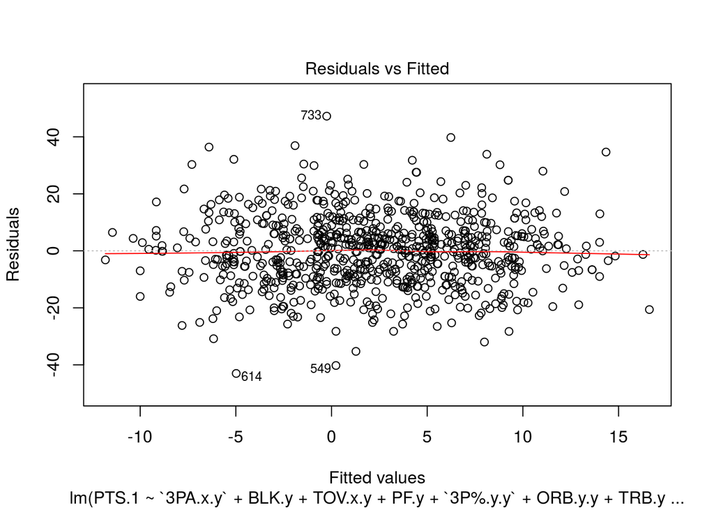

```r
plot(lm.obj.step, which=1)
```

No particular pattern, centered around 0, mostly ranging from $-40$ to $40$.

So we got an idea about the average prediction error. How about predicting the **sign** of the point differential correctly (which automatically determines whether we predict the **winning team** correctly)?

```r
mean(predict(lm.obj.step)*true.diff >= 0)
```

```
## [1] 0.6552632
```

Roughly $65\%$ of correct sign identifications, hence correct predictions of winner/loser.

$65\%$ might be underwhelming, but it will seem even worse once I say that it is an **optimistic** error estimate. We calculated it using the model’s performance on the **same data** that the **model was trained on**. It is a **no-no** when trying to develop a **generalizable model**, meaning a model that will work on the **new data**.

### Model Validation: Training/Testing subset.

To potentially describe how our linear model would work on new data, we refer to sub-dividing our data set into

- Training subset (data used to train the model), and
- Testing (holdout) subset (data used to validate the model performance).

To do this, we randomly sample $80\%$ of indices for observations to be used as training data, while saving the remaining $20\%$ for hold-out testing of our fitted modeL

```r
set.seed(1)
n <- nrow(diff_data)
train <- sample(n,0.8*n)
test <- c(1:n)[-train]

lm.obj <- lm(PTS.1 ~ ., data=diff_data,
             subset = train)
```

We will fit our reduced model only to the observations from **training set** now:

```r
# Just to remind ourselves the names of variables included into our reduced model
# One can simply copy-paste the 'formula' part of the output into the
# subsequent lm() call to fit the model to training data

lm.obj.step
```

```
##
## Call:
## lm(formula = PTS.1 ~ `3PA.x.y` + BLK.y + TOV.x.y + PF.y + `3P%.y.y` +
##     ORB.y.y + TRB.y.y, data = diff_data)
##
## Coefficients:
## (Intercept)    `3PA.x.y`        BLK.y      TOV.x.y         PF.y
##      2.2292       0.5125       1.7401      -1.3726      -0.5445
##   `3P%.y.y`      ORB.y.y      TRB.y.y
##   -115.2842       1.1051      -1.3425
```

```r
lm.obj.train <- lm(PTS.1 ~ `3PA.x.y` + BLK.y + TOV.x.y + PF.y + `3P%.y.y` + ORB.y.y + TRB.y.y,
                   data=diff_data,
                   subset=train)
```

Next, we need to calculate the performance metrics - mean absolute error and sign prediction error - on the **testing (held-out) data**.

```r
test.true <- diff_data[test,'PTS.1']
test.predict <- predict(lm.obj.train,
                        newdata = diff_data[test,-1])

## Mean Absolute Error (MAE) rate on test data.
mean(abs(test.true - test.predict))
```

```
## [1] 10.33501
```

```r
## Proportion of times we predicted the sign correctly
# (positive/negative point differential)
mean(test.true*test.predict>0)
```

```
## [1] 0.6381579
```

But if you were to re-run the post-$set.seed()$ code over and over again, you will see a different result every time, all due to a **different subdivision into training and test data** (the $sample()$ function would provide a different set of indices each time).

## Cross-Validation.

In order to avoid this variability of error estimates, **cross-validation** comes in handy. **$K$-fold cross-validation** consists of

- Breaking the data set into $K$ equally-sized subsets.
- Proceeding to use each of those $K$ subsets as test subset, while using remaining $K-1$ to train the model.
- Obtain $K$ estimates of test set error and average them for a final test error estimate.

All this can be performed via $cv.glm()$ function that comes with $boot$ library. One caveat - we will need to re-run our full linear model fit, now using a $glm()$ function rather than $lm()$. The only reason for this - $lm()$ doesn’t support the automated cross validation function, while $glm()$ does.

The interface of $glm()$ and $lm()$ for the purpose of fitting a classic linear model is identical, only $summary()$ outline differs a bit:

```r
glm.obj <- glm(PTS.1 ~ `3PA.x.y` + BLK.y + TOV.x.y + PF.y + `3P%.y.y` + ORB.y.y + TRB.y.y,
               data=diff_data)
summary(glm.obj)
```

```
##
## Call:
## glm(formula = PTS.1 ~ `3PA.x.y` + BLK.y + TOV.x.y + PF.y + `3P%.y.y` +
##     ORB.y.y + TRB.y.y, data = diff_data)
##
## Deviance Residuals:
##     Min       1Q   Median       3Q      Max
## -43.018   -8.148    0.323    7.022   47.251
##
## Coefficients:
##               Estimate Std. Error t value Pr(>|t|)
## (Intercept)    2.22920    0.44874   4.968 8.39e-07 ***
## `3PA.x.y`      0.51254    0.08639   5.933 4.54e-09 ***
## BLK.y          1.74007    0.48871   3.561 0.000393 ***
## TOV.x.y       -1.37263    0.33926  -4.046 5.75e-05 ***
## PF.y          -0.54451    0.22925  -2.375 0.017788 *
## `3P%.y.y`   -115.28424   26.11473  -4.415 1.16e-05 ***
## ORB.y.y        1.10506    0.53910   2.050 0.040727 *
## TRB.y.y       -1.34253    0.24959  -5.379 1.00e-07 ***
## ---
## Signif. codes:  0 '***' 0.001 '**' 0.01 '*' 0.05 '.' 0.1 ' ' 1
##
## (Dispersion parameter for gaussian family taken to be 152.8925)
##
##     Null deviance: 135745  on 759  degrees of freedom
## Residual deviance: 114975  on 752  degrees of freedom
## AIC: 5989.3
##
## Number of Fisher Scoring iterations: 2
```

Now, let’s load the $boot$ library and run the cross-validation via $cv.glm()$ applied to our fitted model (kept in object $glm.obj$):

```r
library(boot)
set.seed(1)

cv.obj <- cv.glm(data=diff_data,
                 glm.obj,
                 K=10,
                 cost = function(x,y) mean(x*y>0))

cv.obj$delta
```

```
## [1] 0.6473684 0.6459211
```

The $cost$ argument specifies the function of $true$ ($\equiv x$) and $predicted$ ($equiv y$) values of point differentials for our model. What we want is the average of times the signs of predicted point differentials ($y$) corresponded to the actual ones ($x$), which is captured via expression $mean(x*y > 0)$.

The $K=10$-fold cross-validation shows a test error of 64% for our model, a bit worse than the training error, which is expected but isn’t that bad as far as ability of our model to generalize to new data is concerned.